# ASSR2_80Hz

Stefan Wiens & Malina Szychowska

2020-09-22

## Define sample

Note: The analyses use the sample of **all** subjects.

For **all** subjects, 8 pilot subjects were included. These were tested before formal preregistration.  
For **subset** subjects, 8 pilot subjects were excluded.

```r
D=read.csv(file.path(dir_res, paste0("data_audio_signal_noise_N_33.tsv")), sep="\t",header=TRUE, dec=".")
```

```r
if (any(as.numeric(table(D$fp))!=1)){
  stop("Subject numbers are not unique!")
}
```

```r
# the numbers 1 to 2 refer to different blocks

# Amp S-N raw
D$AmpSmNno80Hz = rowMeans(cbind(D$AmpSmNno80_1,D$AmpSmNno80_2))
D$AmpSmNlo80Hz = rowMeans(cbind(D$AmpSmNlo80_1,D$AmpSmNlo80_2))
D$AmpSmNhi80Hz = rowMeans(cbind(D$AmpSmNhi80_1,D$AmpSmNhi80_2))

# Amp S raw
D$AmpSno80Hz = rowMeans(cbind(D$AmpSno80_1,D$AmpSno80_2))
D$AmpSlo80Hz = rowMeans(cbind(D$AmpSlo80_1,D$AmpSlo80_2))
D$AmpShi80Hz = rowMeans(cbind(D$AmpShi80_1,D$AmpShi80_2))

# Amp N raw
D$AmpNno80Hz = rowMeans(cbind(D$AmpNno80_1,D$AmpNno80_2))
D$AmpNlo80Hz = rowMeans(cbind(D$AmpNlo80_1,D$AmpNlo80_2))
D$AmpNhi80Hz = rowMeans(cbind(D$AmpNhi80_1,D$AmpNhi80_2))

# Amp SNR raw
D$AmpSNRno80Hz = rowMeans(cbind(D$AmpSNRno80_1,D$AmpSNRno80_2))
D$AmpSNRlo80Hz = rowMeans(cbind(D$AmpSNRlo80_1,D$AmpSNRlo80_2))
D$AmpSNRhi80Hz = rowMeans(cbind(D$AmpSNRhi80_1,D$AmpSNRhi80_2))
```

```r
# the numbers 1 to 2 refer to different blocks

# ITC S-N raw
D$ItcSmNno80Hz = rowMeans(cbind(D$ItcSmNno80_1,D$ItcSmNno80_2))
D$ItcSmNlo80Hz = rowMeans(cbind(D$ItcSmNlo80_1,D$ItcSmNlo80_2))
D$ItcSmNhi80Hz = rowMeans(cbind(D$ItcSmNhi80_1,D$ItcSmNhi80_2))

# ITC S raw
D$ItcSno80Hz = rowMeans(cbind(D$ItcSno80_1,D$ItcSno80_2))
D$ItcSlo80Hz = rowMeans(cbind(D$ItcSlo80_1,D$ItcSlo80_2))
D$ItcShi80Hz = rowMeans(cbind(D$ItcShi80_1,D$ItcShi80_2))

# ITC N raw
D$ItcNno80Hz = rowMeans(cbind(D$ItcNno80_1,D$ItcNno80_2))
D$ItcNlo80Hz = rowMeans(cbind(D$ItcNlo80_1,D$ItcNlo80_2))
D$ItcNhi80Hz = rowMeans(cbind(D$ItcNhi80_1,D$ItcNhi80_2))

# ITC SNR raw
D$ItcSNRno80Hz = rowMeans(cbind(D$ItcSNRno80_1,D$ItcSNRno80_2))
D$ItcSNRlo80Hz = rowMeans(cbind(D$ItcSNRlo80_1,D$ItcSNRlo80_2))
D$ItcSNRhi80Hz = rowMeans(cbind(D$ItcSNRhi80_1,D$ItcSNRhi80_2))
```

```r
Dsel_amp = D %>% filter(
  D$AmpSmNno80Hz > 0.1 | D$AmpSmNlo80Hz > 0.1 | D$AmpSmNhi80Hz > 0.1
  )

Dsel2_amp = D %>% filter(
  D$AmpSmNno80Hz > 0.1 & D$AmpSmNlo80Hz > 0.1 & D$AmpSmNhi80Hz > 0.1
  )

Dsel_itc = D %>% filter(
  D$ItcSmNno80Hz > 0.1 | D$ItcSmNlo80Hz > 0.1 | D$ItcSmNhi80Hz > 0.1
  )

Dsel2_itc = D %>% filter(
  D$ItcSmNno80Hz > 0.1 & D$ItcSmNlo80Hz > 0.1 & D$ItcSmNhi80Hz > 0.1
  )
```

## Quick look at SmN for 80-Hz ASSRs:

**For all subjects:**  
Amplitude (N = 33):  
No load = 0.099  
Low load = 0.103  
High load = 0.092

ITC (N = 33): :  
No load = 0.127  
Low load = 0.116  
High load = 0.103

**For those who have at least one SmN > 0.1:**  
Amplitude (N = 19):  
No load = 0.148  
Low load = 0.147  
High load = 0.144

ITC (N = 20): :  
No load = 0.183  
Low load = 0.173  
High load = 0.141

**For those who have all SmN > 0.1:**  
Amplitude (N = 7):  
No load = 0.242  
Low load = 0.235  
High load = 0.249

## ASSR means and prereg BFs

Means and preregistered Bayes factors.

### Ampl SmN

Amplitude signal minus noise (SmN)

#### plot

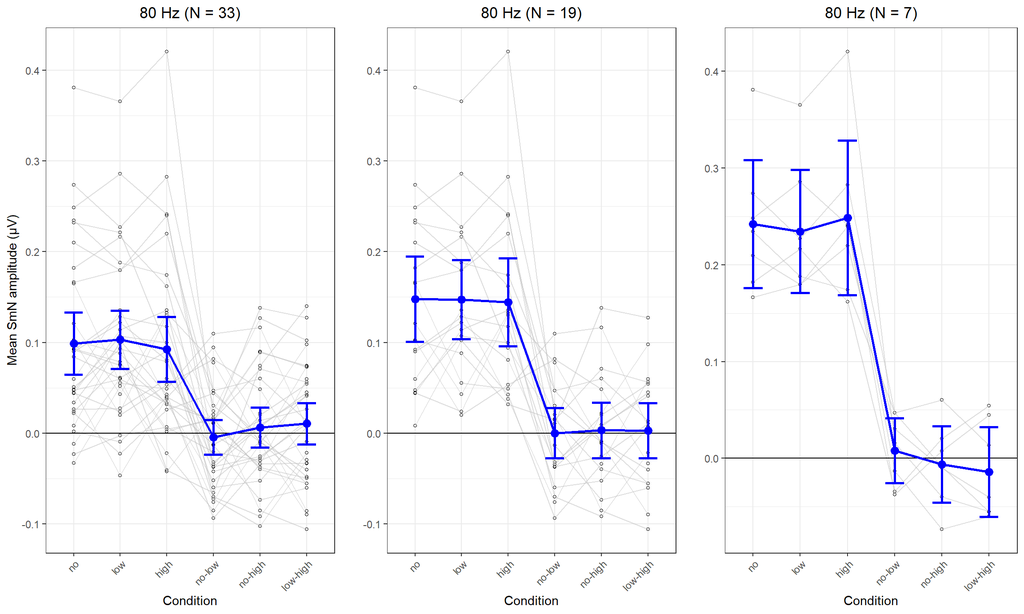

```r
iv = "AmpSmN"
Dtmp = getdiffs(D, iv = iv)
myylim = c(min(Dtmp), max(Dtmp))
Dtmp = Dtmp[,c(4:9)]
Dtmp = cbind(D$fp, Dtmp)
colnames(Dtmp) = c('fp', 'no', 'low', 'high', 'no-low', 'no-high', 'low-high')
bp1a = plotoverlay(dm = Dtmp,lbl = paste0("80 Hz"), dvy = "Mean SmN amplitude (µV)", myylim)

Dtmp_sel = getdiffs(Dsel_amp, iv = iv)
myylim = c(min(Dtmp_sel), max(Dtmp_sel))
Dtmp_sel = Dtmp_sel[,c(4:9)]
Dtmp_sel = cbind(Dsel_amp$fp, Dtmp_sel)
colnames(Dtmp_sel) = c('fp', 'no', 'low', 'high', 'no-low', 'no-high', 'low-high')
bp1b = plotoverlay(dm = Dtmp_sel,lbl = paste0("80 Hz"), dvy = "", myylim)

Dtmp_sel2 = getdiffs(Dsel2_amp, iv = iv)
myylim = c(min(Dtmp_sel2), max(Dtmp_sel2))
Dtmp_sel2 = Dtmp_sel2[,c(4:9)]
Dtmp_sel2 = cbind(Dsel2_amp$fp, Dtmp_sel2)
colnames(Dtmp_sel2) = c('fp', 'no', 'low', 'high', 'no-low', 'no-high', 'low-high')
bp1c = plotoverlay(dm = Dtmp_sel2,lbl = paste0("80 Hz"), dvy = "", myylim)


grid.arrange(bp1a, bp1b, bp1c, ncol = 3)
```

```r
bp1 = arrangeGrob(bp1a, bp1b, bp1c, ncol = 3)
ggsave(file.path(dir_fig,"figure_amp_80Hz_sel.jpg"), bp1, dpi = 600, width = 7, height = 4)
ggsave(file.path(dir_fig,"figure_amp_80Hz_sel.pdf"), bp1, dpi = 600, width = 7, height = 4)

Dtmp_amp = Dtmp # save for later
Dtmp_amp_sel = Dtmp_sel # save for later
Dtmp_amp_sel2 = Dtmp_sel2 # save for later
```

#### table

```r
iv = "AmpSmN"
Dtmp = getdiffs(D, iv = iv)
Dtmp = tableCIs(Dtmp[,c(4:9)])
Dtmp = Dtmp[1:4]
#Dtmp$sample = 'complete'

Dtmp_sel = getdiffs(Dsel_amp, iv = iv)
Dtmp_sel = tableCIs(Dtmp_sel[,c(4:9)])
Dtmp_sel = Dtmp_sel[2:4]
#Dtmp_sel$sample = 'sel any > 0.1'

Dtmp_sel2 = getdiffs(Dsel2_amp, iv = iv)
Dtmp_sel2 = tableCIs(Dtmp_sel2[,c(4:9)])
Dtmp_sel2 = Dtmp_sel2[2:4]
#Dtmp_sel2$sample = 'sel all > 0.1'

Dtmp_all = cbind(Dtmp, Dtmp_sel, Dtmp_sel2)

Dtmp_all %>%
  kable(digits = 3) %>%
  kable_styling(bootstrap_options = c("striped", "hover", "condensed"),
                full_width = F, position = 'left') %>%
  add_header_above(c(" " = 1, "complete (N = 33)" = 3, "any > 0.1 (N = 19)" = 3, "all > 0.1 (N = 7)" = 3))
```

| Variable | complete (N = 33) Mean | complete (N = 33) LL | complete (N = 33) UL | any > 0.1 (N = 19) Mean | any > 0.1 (N = 19) LL | any > 0.1 (N = 19) UL | all > 0.1 (N = 7) Mean | all > 0.1 (N = 7) LL | all > 0.1 (N = 7) UL |
| --- | --- | --- | --- | --- | --- | --- | --- | --- | --- |
| no80Hz | 0.099 | 0.064 | 0.133 | 0.148 | 0.101 | 0.195 | 0.242 | 0.176 | 0.308 |
| lo80Hz | 0.103 | 0.071 | 0.135 | 0.147 | 0.104 | 0.191 | 0.235 | 0.171 | 0.298 |
| hi80Hz | 0.092 | 0.057 | 0.128 | 0.144 | 0.096 | 0.193 | 0.249 | 0.169 | 0.328 |
| no-lo80Hz | -0.004 | -0.023 | 0.015 | 0.000 | -0.028 | 0.028 | 0.008 | -0.026 | 0.041 |
| no-hi80Hz | 0.006 | -0.016 | 0.028 | 0.003 | -0.027 | 0.034 | -0.006 | -0.046 | 0.033 |
| lo-hi80Hz | 0.011 | -0.012 | 0.033 | 0.003 | -0.027 | 0.033 | -0.014 | -0.061 | 0.032 |

#### preregistered BFs

The BFs are computed from Bayesian one-sample t tests of difference scores (with Aladins R script).  
https://doi.org/10.17045/sthlmuni.4981154.v3

The BF01 uses uniform H1 models with different lower limits (LL) and upper limits (UL).  
BF01 is the evidence for the null hypothesis relative to the alternative hypothesis.  
If BF01 > 3, this is evidence for the null. If BF01 < 1/3, this is evidence against the null.

```r
Dtmp = contrastBFs(D, iv = iv)
Dtmp$sample = 'complete'

Dtmp_sel = contrastBFs(Dsel_amp, iv = iv)
Dtmp_sel$sample = 'any > 0.1'

Dtmp_sel2 = contrastBFs(Dsel2_amp, iv = iv)
Dtmp_sel2$sample = 'all > 0.1'

Dtmp_all = rbind(Dtmp, Dtmp_sel, Dtmp_sel2)

Dtmp_all %>%
  kable(digits = 3,
        col.names = c('Variable','Mean','[-1, +1]','[0, +1]','[0, +0.24]','[0, +0.37]','sample')) %>%
  add_header_above(c(" " = 2, "BF01" = 4, " " = 1)) %>%
  kable_styling(bootstrap_options = c("striped", "hover", "condensed"),
                full_width = F, position = 'left')
```

| Variable | Mean | BF01 [-1, +1] | BF01 [0, +1] | BF01 [0, +0.24] | BF01 [0, +0.37] | sample |
| --- | --- | --- | --- | --- | --- | --- |
| no-lo80Hz | -0.004 | 75.729 | 110.887 | 27.795 | 42.530 | complete |
| no-hi80Hz | 0.006 | 61.778 | 42.256 | 10.305 | 15.843 | complete |
| lo-hi80Hz | 0.011 | 44.927 | 26.853 | 6.510 | 10.018 | complete |
| no-lo80Hz | 0.000 | 59.858 | 57.852 | 14.196 | 21.802 | any > 0.1 |
| no-hi80Hz | 0.003 | 52.986 | 44.336 | 10.822 | 16.635 | any > 0.1 |
| lo-hi80Hz | 0.003 | 53.211 | 44.659 | 10.902 | 16.758 | any > 0.1 |
| no-lo80Hz | 0.008 | 46.614 | 32.558 | 7.911 | 12.170 | all > 0.1 |
| no-hi80Hz | -0.006 | 43.439 | 59.399 | 14.587 | 22.399 | all > 0.1 |
| lo-hi80Hz | -0.014 | 29.698 | 59.225 | 14.544 | 22.333 | all > 0.1 |

### ITC SmN

Intertrial coherence signal minus noise (SmN)

#### plot

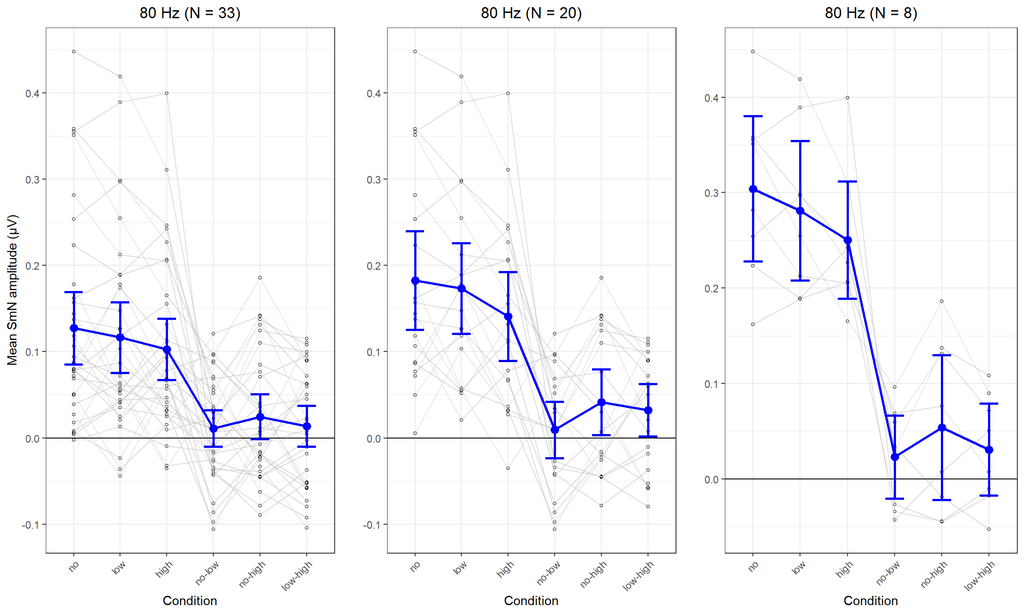

```r
iv = "ItcSmN"

Dtmp = getdiffs(D, iv = iv)
myylim = c(min(Dtmp), max(Dtmp))
Dtmp = Dtmp[,c(4:9)]
Dtmp = cbind(D$fp, Dtmp)
colnames(Dtmp) = c('fp', 'no', 'low', 'high', 'no-low', 'no-high', 'low-high')
bp1a = plotoverlay(dm = Dtmp,lbl = paste0("80 Hz"), dvy = "Mean SmN amplitude (µV)", myylim)

Dtmp_sel = getdiffs(Dsel_itc, iv = iv)
myylim = c(min(Dtmp_sel), max(Dtmp_sel))
Dtmp_sel = Dtmp_sel[,c(4:9)]
Dtmp_sel = cbind(Dsel_itc$fp, Dtmp_sel)
colnames(Dtmp_sel) = c('fp', 'no', 'low', 'high', 'no-low', 'no-high', 'low-high')
bp1b = plotoverlay(dm = Dtmp_sel,lbl = paste0("80 Hz"), dvy = "", myylim)

Dtmp_sel2 = getdiffs(Dsel2_itc, iv = iv)
myylim = c(min(Dtmp_sel2), max(Dtmp_sel2))
Dtmp_sel2 = Dtmp_sel2[,c(4:9)]
Dtmp_sel2 = cbind(Dsel2_itc$fp, Dtmp_sel2)
colnames(Dtmp_sel2) = c('fp', 'no', 'low', 'high', 'no-low', 'no-high', 'low-high')
bp1c = plotoverlay(dm = Dtmp_sel2,lbl = paste0("80 Hz"), dvy = "", myylim)

grid.arrange(bp1a, bp1b, bp1c, ncol = 3)
```

```r
bp1 = arrangeGrob(bp1a, bp1b, bp1c, ncol = 3)
ggsave(file.path(dir_fig,"figure_itc_80Hz_sel.jpg"), bp1, dpi = 600, width = 7, height = 4)
ggsave(file.path(dir_fig,"figure_itc_80Hz_sel.pdf"), bp1, dpi = 600, width = 7, height = 4)

Dtmp_itc = Dtmp # save for later
Dtmp_itc_sel = Dtmp_sel # save for later
Dtmp_itc_sel2 = Dtmp_sel2 # save for later
```

#### table

```r
iv = "ItcSmN"
Dtmp = getdiffs(D, iv = iv)
Dtmp = tableCIs(Dtmp[,c(4:9)])
Dtmp = Dtmp[1:4]
#Dtmp$sample = 'complete'

Dtmp_sel = getdiffs(Dsel_itc, iv = iv)
Dtmp_sel = tableCIs(Dtmp_sel[,c(4:9)])
Dtmp_sel = Dtmp_sel[2:4]
#Dtmp_sel$sample = 'sel any > 0.1'

Dtmp_sel2 = getdiffs(Dsel2_itc, iv = iv)
Dtmp_sel2 = tableCIs(Dtmp_sel2[,c(4:9)])
Dtmp_sel2 = Dtmp_sel2[2:4]
#Dtmp_sel2$sample = 'sel all > 0.1'

Dtmp_all = cbind(Dtmp, Dtmp_sel, Dtmp_sel2)

Dtmp_all %>%
  kable(digits = 3) %>%
  kable_styling(bootstrap_options = c("striped", "hover", "condensed"),
                full_width = F, position = 'left') %>%
  add_header_above(c(" " = 1, "complete (N = 33)" = 3, "any > 0.1 (N = 20)" = 3, "all > 0.1 (N = 8)" = 3))
```

| Variable | complete (N = 33) Mean | complete (N = 33) LL | complete (N = 33) UL | any > 0.1 (N = 20) Mean | any > 0.1 (N = 20) LL | any > 0.1 (N = 20) UL | all > 0.1 (N = 8) Mean | all > 0.1 (N = 8) LL | all > 0.1 (N = 8) UL |
| --- | --- | --- | --- | --- | --- | --- | --- | --- | --- |
| no80Hz | 0.127 | 0.085 | 0.169 | 0.183 | 0.126 | 0.240 | 0.304 | 0.228 | 0.380 |
| lo80Hz | 0.116 | 0.076 | 0.157 | 0.173 | 0.121 | 0.226 | 0.281 | 0.208 | 0.354 |
| hi80Hz | 0.103 | 0.067 | 0.138 | 0.141 | 0.089 | 0.192 | 0.250 | 0.189 | 0.312 |
| no-lo80Hz | 0.011 | -0.010 | 0.032 | 0.009 | -0.023 | 0.042 | 0.023 | -0.021 | 0.067 |
| no-hi80Hz | 0.025 | -0.001 | 0.051 | 0.042 | 0.004 | 0.080 | 0.054 | -0.022 | 0.130 |
| lo-hi80Hz | 0.014 | -0.010 | 0.038 | 0.032 | 0.002 | 0.063 | 0.031 | -0.017 | 0.079 |

#### preregistered BFs

The BFs are computed from Bayesian one-sample t tests of difference scores (with Aladins R script).  
https://doi.org/10.17045/sthlmuni.4981154.v3

The BF01 uses uniform H1 models with different lower limits (LL) and upper limits (UL).  
BF01 is the evidence for the null hypothesis relative to the alternative hypothesis.  
If BF01 > 3, this is evidence for the null. If BF01 < 1/3, this is evidence against the null.

```r
Dtmp = contrastBFs(D, iv = iv)
Dtmp$sample = 'complete'

Dtmp_sel = contrastBFs(Dsel_itc, iv = iv)
Dtmp_sel$sample = 'any > 0.1'

Dtmp_sel2 = contrastBFs(Dsel2_itc, iv = iv)
Dtmp_sel2$sample = 'all > 0.1'

Dtmp_all = rbind(Dtmp, Dtmp_sel, Dtmp_sel2)

Dtmp_all %>%
  kable(digits = 3,
        col.names = c('Variable','Mean','[-1, +1]','[0, +1]','[0, +0.24]','[0, +0.37]','sample')) %>%
  add_header_above(c(" " = 2, "BF01" = 4, " " = 1)) %>%
  kable_styling(bootstrap_options = c("striped", "hover", "condensed"),
                full_width = F, position = 'left')
```

| Variable | Mean | BF01 [-1, +1] | BF01 [0, +1] | BF01 [0, +0.24] | BF01 [0, +0.37] | sample |
| --- | --- | --- | --- | --- | --- | --- |
| no-lo80Hz | 0.011 | 43.737 | 25.432 | 6.162 | 9.484 | complete |
| no-hi80Hz | 0.025 | 10.113 | 5.207 | 1.252 | 1.929 | complete |
| lo-hi80Hz | 0.014 | 33.898 | 19.191 | 4.639 | 7.143 | complete |
| no-lo80Hz | 0.010 | 41.626 | 28.356 | 6.879 | 10.585 | any > 0.1 |
| no-hi80Hz | 0.042 | 3.787 | 1.924 | 0.462 | 0.712 | any > 0.1 |
| lo-hi80Hz | 0.032 | 5.497 | 2.800 | 0.673 | 1.037 | any > 0.1 |
| no-lo80Hz | 0.023 | 18.814 | 10.719 | 2.583 | 3.979 | all > 0.1 |
| no-hi80Hz | 0.054 | 6.267 | 3.361 | 0.808 | 1.245 | all > 0.1 |
| lo-hi80Hz | 0.031 | 12.244 | 6.684 | 1.608 | 2.478 | all > 0.1 |

## Exploratory BFs

In the preregistered BF analyses, we defined upper limits of the priors on the basis of the mean SmN values for no load in a previous study with 40-Hz ASSRs (Study 2 in Szychowska & Wiens, 2020). Theoretically, the SmN during no load defines an upper limit of how strong the task effect and load effect can be.

Because the visual task in the present study was identical to that in the previous study, we anticipated that we would observe similar mean SmN values during no load for 40-Hz. So, we used our previous data to predict the upper limits for 40 Hz. For simplicity, we used these upper limits also for 20 and 80 Hz. Thus, the original goal was to define realistic upper limits in the BF analyses and to preregister these limits to facilitate confirmatory research (hypothesis testing).

However, the present results showed that the **actual** SmN during no and low load differed from the preregistered upper limits. To conduct BF analyses that matched our original goal of using reasonable upper limits, we defined the upper limits on the basis of the present data, separately for each measure and frequency.

**No minus low/high**  
One analysis considered **no load** as the baseline, and the H1 model was defined as a uniform distribution between 0 (as lower limit, LL) and the present mean of no load (as upper limit, UL).

No minus low = task effect  
No minus high = combined effect of task and load

**Low minus high**  
The other analysis considered **low load** as the baseline, and the H1 model was defined as a uniform distribution between 0 (as lower limit, LL) and the present mean of low load (as upper limit, UL).

Low minus high = load effect

In the table, LL and UL refer to the 95% CIs of the means (and not to the LL and UL of the H1 models).

```r
# complete sample
Dtmpa = subset(Dtmp_amp,
               select=c(fp, no, low, high))
colnames(Dtmpa) = c('fp', 'AmpSmNno', 'AmpSmNlo', 'AmpSmNhi')
Dtmpi = subset(Dtmp_itc,
               select=c(no, low, high))
colnames(Dtmpi) = c('ItcSmNno', 'ItcSmNlo', 'ItcSmNhi')
Dtmp = cbind(Dtmpa, Dtmpi)
Dtmp$sample = 'complete'
Dtmpi$sample = 'complete'
Dtmpa$sample = 'complete'

# any > 0.1
Dtmpa_sel = subset(Dtmp_amp_sel,
               select=c(fp, no, low, high))
colnames(Dtmpa_sel) = c('fp', 'AmpSmNno', 'AmpSmNlo', 'AmpSmNhi')
Dtmpi_sel = subset(Dtmp_itc_sel,
               select=c(fp, no, low, high))
colnames(Dtmpi_sel) = c('fp','ItcSmNno', 'ItcSmNlo', 'ItcSmNhi')
#Dtmp_sel = cbind(Dtmpa_sel, Dtmpi_sel)
Dtmpi_sel$sample = 'any > 0.1'
Dtmpa_sel$sample = 'any > 0.1'

# all > 0.1
Dtmpa_sel2 = subset(Dtmp_amp_sel2,
               select=c(fp, no, low, high))
colnames(Dtmpa_sel2) = c('fp', 'AmpSmNno', 'AmpSmNlo', 'AmpSmNhi')
Dtmpi_sel2 = subset(Dtmp_itc_sel2,
               select=c(fp, no, low, high))
colnames(Dtmpi_sel2) = c('fp','ItcSmNno', 'ItcSmNlo', 'ItcSmNhi')
#Dtmp_sel2 = cbind(Dtmpa_sel2, Dtmpi_sel2)
Dtmpi_sel2$sample = 'all > 0.1'
Dtmpa_sel2$sample = 'all > 0.1'
```

### load effect: low minus high

```r
DBF10 = numeric()

# create matrix with measure, study, n, mean high load,
# diff hiMlo, LL 95%CI, UL 95%CI, BF10 hiMlo, BF01 hiMlo,
LL = 0

# amp
# complete
UL = mean(Dtmp$AmpSmNlo)
tmp = Dtmp$AmpSmNlo-Dtmp$AmpSmNhi
DBF10 = rbind(DBF10, c('complete','Amp', nrow(Dtmp), UL,
                       mean(tmp), ci(tmp), 1/BFfitH1(LL = 0, UL, tmp), BFfitH1(LL = 0, UL, tmp)))

# any > 0.1
UL = mean(Dtmpa_sel$AmpSmNlo)
tmp = Dtmpa_sel$AmpSmNlo-Dtmpa_sel$AmpSmNhi
DBF10 = rbind(DBF10, c('any > 0.1','Amp', nrow(Dtmpa_sel), UL,
                       mean(tmp), ci(tmp), 1/BFfitH1(LL = 0, UL, tmp), BFfitH1(LL = 0, UL, tmp)))

# all > 0.1
UL = mean(Dtmpa_sel2$AmpSmNlo)
tmp = Dtmpa_sel2$AmpSmNlo-Dtmpa_sel2$AmpSmNhi
DBF10 = rbind(DBF10, c('all > 0.1', 'Amp', nrow(Dtmpa_sel2), UL,
                       mean(tmp), ci(tmp), 1/BFfitH1(LL = 0, UL, tmp), BFfitH1(LL = 0, UL, tmp)))

# itc
# complete
UL = mean(Dtmp$ItcSmNlo)
tmp = Dtmp$ItcSmNlo-Dtmp$ItcSmNhi
DBF10 = rbind(DBF10, c('complete','Itc', nrow(Dtmp), UL,
                       mean(tmp), ci(tmp), 1/BFfitH1(LL = 0, UL, tmp), BFfitH1(LL = 0, UL, tmp)))

# any > 0.1
UL = mean(Dtmpi_sel$ItcSmNlo)
tmp = Dtmpi_sel$ItcSmNlo-Dtmpi_sel$ItcSmNhi
DBF10 = rbind(DBF10, c('any > 0.1','Itc', nrow(Dtmpi_sel), UL,
                       mean(tmp), ci(tmp), 1/BFfitH1(LL = 0, UL, tmp), BFfitH1(LL = 0, UL, tmp)))

# all > 0.1
UL = mean(Dtmpi_sel2$ItcSmNlo)
tmp = Dtmpi_sel2$ItcSmNlo-Dtmpi_sel2$ItcSmNhi
DBF10 = rbind(DBF10, c('all > 0.1', 'Itc', nrow(Dtmpi_sel2), UL,
                       mean(tmp), ci(tmp), 1/BFfitH1(LL = 0, UL, tmp), BFfitH1(LL = 0, UL, tmp)))

DBF10 = as.data.frame(DBF10)
colnames(DBF10)=c('Sample','Measure','N','Mhi',
                  'M-loMhi','LL-loMhi','UL-loMhi','BF10-loMhi','BF01-loMhi')

# convert character to numeric
i = 3:9
DBF10[, i] = apply(DBF10[,i],2, function(x) as.numeric(as.character(x)))
DBF10 %>%
  kable(digits = 3,
        col.names = c('Sample','Measure','N','Mean',
                      'Mean','LL', 'UL', 'BF10', 'BF01')) %>%
  kable_styling(bootstrap_options = c("striped", "hover", "condensed"),
                full_width = F, position = 'left') %>%
  add_header_above(c(" " = 3, "low" = 1, "low minus high" = 5))
```

| Sample | Measure | N | low Mean | low minus high Mean | low minus high LL | low minus high UL | low minus high BF10 | low minus high BF01 |
| --- | --- | --- | --- | --- | --- | --- | --- | --- |
| complete | Amp | 33 | 0.103 | 0.011 | -0.012 | 0.033 | 0.357 | 2.801 |
| any > 0.1 | Amp | 19 | 0.147 | 0.003 | -0.027 | 0.033 | 0.149 | 6.707 |
| all > 0.1 | Amp | 7 | 0.235 | -0.014 | -0.061 | 0.032 | 0.070 | 14.214 |
| complete | Itc | 33 | 0.116 | 0.014 | -0.010 | 0.038 | 0.444 | 2.254 |
| any > 0.1 | Itc | 20 | 0.173 | 0.032 | 0.002 | 0.063 | 2.060 | 0.485 |
| all > 0.1 | Itc | 8 | 0.281 | 0.031 | -0.017 | 0.079 | 0.531 | 1.884 |

### task effect: no minus low

```r
# compare low with no load
DBF10 = numeric()

# create matrix with measure, study, n, mean low load,
# diff loMhi, LL 95%CI, UL 95%CI, BF01 loMhi
LL = 0

# amp
# complete
UL = mean(Dtmp$AmpSmNno)
tmp = Dtmp$AmpSmNno-Dtmp$AmpSmNlo
DBF10 = rbind(DBF10, c('complete','Amp', nrow(Dtmp), UL,
                       mean(tmp), ci(tmp), 1/BFfitH1(LL = 0, UL, tmp), BFfitH1(LL = 0, UL, tmp)))

# any > 0.1
UL = mean(Dtmpa_sel$AmpSmNno)
tmp = Dtmpa_sel$AmpSmNno-Dtmpa_sel$AmpSmNlo
DBF10 = rbind(DBF10, c('any > 0.1','Amp', nrow(Dtmpa_sel), UL,
                       mean(tmp), ci(tmp), 1/BFfitH1(LL = 0, UL, tmp), BFfitH1(LL = 0, UL, tmp)))

# all > 0.1
UL = mean(Dtmpa_sel2$AmpSmNno)
tmp = Dtmpa_sel2$AmpSmNno-Dtmpa_sel2$AmpSmNlo
DBF10 = rbind(DBF10, c('all > 0.1', 'Amp', nrow(Dtmpa_sel2), UL,
                       mean(tmp), ci(tmp), 1/BFfitH1(LL = 0, UL, tmp), BFfitH1(LL = 0, UL, tmp)))

# itc
# complete
UL = mean(Dtmp$ItcSmNno)
tmp = Dtmp$ItcSmNno-Dtmp$ItcSmNlo
DBF10 = rbind(DBF10, c('complete','Itc', nrow(Dtmp), UL,
                       mean(tmp), ci(tmp), 1/BFfitH1(LL = 0, UL, tmp), BFfitH1(LL = 0, UL, tmp)))

# any > 0.1
UL = mean(Dtmpi_sel$ItcSmNno)
tmp = Dtmpi_sel$ItcSmNno-Dtmpi_sel$ItcSmNlo
DBF10 = rbind(DBF10, c('any > 0.1','Itc', nrow(Dtmpi_sel), UL,
                       mean(tmp), ci(tmp), 1/BFfitH1(LL = 0, UL, tmp), BFfitH1(LL = 0, UL, tmp)))

# all > 0.1
UL = mean(Dtmpi_sel2$ItcSmNno)
tmp = Dtmpi_sel2$ItcSmNno-Dtmpi_sel2$ItcSmNlo
DBF10 = rbind(DBF10, c('all > 0.1', 'Itc', nrow(Dtmpi_sel2), UL,
                       mean(tmp), ci(tmp), 1/BFfitH1(LL = 0, UL, tmp), BFfitH1(LL = 0, UL, tmp)))

DBF10 = as.data.frame(DBF10)
colnames(DBF10)=c('Sample','Measure','N','Mhi',
                  'M-loMhi','LL-loMhi','UL-loMhi','BF10-loMhi','BF01-loMhi')

# convert character to numeric
i = 3:9
DBF10[, i] = apply(DBF10[,i],2, function(x) as.numeric(as.character(x)))
DBF10 %>%
  kable(digits = 3,
        col.names = c('Sample','Measure','N','Mean',
                      'Mean','LL', 'UL', 'BF10', 'BF01')) %>%
  kable_styling(bootstrap_options = c("striped", "hover", "condensed"),
                full_width = F, position = 'left') %>%
  add_header_above(c(" " = 3, "no" = 1, "no minus low" = 5))
```

| Sample | Measure | N | no Mean | no minus low Mean | no minus low LL | no minus low UL | no minus low BF10 | no minus low BF01 |
| --- | --- | --- | --- | --- | --- | --- | --- | --- |
| complete | Amp | 33 | 0.099 | -0.004 | -0.023 | 0.015 | 0.087 | 11.529 |
| any > 0.1 | Amp | 19 | 0.148 | 0.000 | -0.028 | 0.028 | 0.113 | 8.821 |
| all > 0.1 | Amp | 7 | 0.242 | 0.008 | -0.026 | 0.041 | 0.125 | 7.986 |
| complete | Itc | 33 | 0.127 | 0.011 | -0.010 | 0.032 | 0.305 | 3.274 |
| any > 0.1 | Itc | 20 | 0.183 | 0.009 | -0.023 | 0.042 | 0.190 | 5.261 |
| all > 0.1 | Itc | 8 | 0.304 | 0.023 | -0.021 | 0.067 | 0.306 | 3.268 |

### combined effect: no minus high

In the table, LL and UL refer to the 95% CIs of the means (and not to the LL and UL of the H1 models).

```r
DBF10 = numeric()

# create matrix with measure, study, n, mean no load,
# diff hiMno, LL 95%CI, UL 95%CI, BF10 hiMno, BF01 hiMno,
# diff hiMlo, LL 95%CI, UL 95%CI, BF10 hiMlo, BF01 hiMlo,
LL = 0

# amp
# complete
UL = mean(Dtmp$AmpSmNno)
tmp = Dtmp$AmpSmNno-Dtmp$AmpSmNhi
DBF10 = rbind(DBF10, c('complete','Amp', nrow(Dtmp), UL,
                       mean(tmp), ci(tmp), 1/BFfitH1(LL = 0, UL, tmp), BFfitH1(LL = 0, UL, tmp)))

# any > 0.1
UL = mean(Dtmpa_sel$AmpSmNno)
tmp = Dtmpa_sel$AmpSmNno-Dtmpa_sel$AmpSmNhi
DBF10 = rbind(DBF10, c('any > 0.1','Amp', nrow(Dtmpa_sel), UL,
                       mean(tmp), ci(tmp), 1/BFfitH1(LL = 0, UL, tmp), BFfitH1(LL = 0, UL, tmp)))

# all > 0.1
UL = mean(Dtmpa_sel2$AmpSmNno)
tmp = Dtmpa_sel2$AmpSmNno-Dtmpa_sel2$AmpSmNhi
DBF10 = rbind(DBF10, c('all > 0.1', 'Amp', nrow(Dtmpa_sel2), UL,
                       mean(tmp), ci(tmp), 1/BFfitH1(LL = 0, UL, tmp), BFfitH1(LL = 0, UL, tmp)))

# itc
# complete
UL = mean(Dtmp$ItcSmNno)
tmp = Dtmp$ItcSmNno-Dtmp$ItcSmNhi
DBF10 = rbind(DBF10, c('complete','Itc', nrow(Dtmp), UL,
                       mean(tmp), ci(tmp), 1/BFfitH1(LL = 0, UL, tmp), BFfitH1(LL = 0, UL, tmp)))

# any > 0.1
UL = mean(Dtmpi_sel$ItcSmNno)
tmp = Dtmpi_sel$ItcSmNno-Dtmpi_sel$ItcSmNhi
DBF10 = rbind(DBF10, c('any > 0.1','Itc', nrow(Dtmpi_sel), UL,
                       mean(tmp), ci(tmp), 1/BFfitH1(LL = 0, UL, tmp), BFfitH1(LL = 0, UL, tmp)))

# all > 0.1
UL = mean(Dtmpi_sel2$ItcSmNno)
tmp = Dtmpi_sel2$ItcSmNno-Dtmpi_sel2$ItcSmNhi
DBF10 = rbind(DBF10, c('all > 0.1', 'Itc', nrow(Dtmpi_sel2), UL,
                       mean(tmp), ci(tmp), 1/BFfitH1(LL = 0, UL, tmp), BFfitH1(LL = 0, UL, tmp)))

DBF10 = as.data.frame(DBF10)
colnames(DBF10)=c('Sample','Measure','N','Mhi',
                  'M-loMhi','LL-loMhi','UL-loMhi','BF10-loMhi','BF01-loMhi')

# convert character to numeric
i = 3:9
DBF10[, i] = apply(DBF10[,i],2, function(x) as.numeric(as.character(x)))
DBF10 %>%
  kable(digits = 3,
        col.names = c('Sample','Measure','N','Mean',
                      'Mean','LL', 'UL', 'BF10', 'BF01')) %>%
  kable_styling(bootstrap_options = c("striped", "hover", "condensed"),
                full_width = F, position = 'left') %>%
  add_header_above(c(" " = 3, "no" = 1, "no minus high" = 5))
```

| Sample | Measure | N | no Mean | no minus high Mean | no minus high LL | no minus high UL | no minus high BF10 | no minus high BF01 |
| --- | --- | --- | --- | --- | --- | --- | --- | --- |
| complete | Amp | 33 | 0.099 | 0.006 | -0.016 | 0.028 | 0.235 | 4.252 |
| any > 0.1 | Amp | 19 | 0.148 | 0.003 | -0.027 | 0.034 | 0.149 | 6.706 |
| all > 0.1 | Amp | 7 | 0.242 | -0.006 | -0.046 | 0.033 | 0.068 | 14.724 |
| complete | Itc | 33 | 0.127 | 0.025 | -0.001 | 0.051 | 1.505 | 0.665 |
| any > 0.1 | Itc | 20 | 0.183 | 0.042 | 0.004 | 0.080 | 2.845 | 0.351 |
| all > 0.1 | Itc | 8 | 0.304 | 0.054 | -0.022 | 0.130 | 0.978 | 1.022 |